# Risk Factor Analysis

## Outcome Variable

**Outcome Variable:** stunted

## Predictor Variables

**Intervention Variable:** mbmi

**Adjustment Set:**

unadjusted

## Stratifying Variables

The analysis was stratified on these variable(s):

- agecat
- studyid
- country

## Data Summary

| agecat | studyid | country | A | n | nA | nAY0 | nAY1 |
| --- | --- | --- | --- | --- | --- | --- | --- |
| Birth | ki0047075b-MAL-ED | BANGLADESH | [18.5-25) | 246 | 158 | 130 | 28 |
| Birth | ki0047075b-MAL-ED | BANGLADESH | <18.5 | 246 | 30 | 25 | 5 |
| Birth | ki0047075b-MAL-ED | BANGLADESH | [25-30) | 246 | 52 | 47 | 5 |
| Birth | ki0047075b-MAL-ED | BANGLADESH | >=30 | 246 | 6 | 2 | 4 |
| Birth | ki0047075b-MAL-ED | BRAZIL | [18.5-25) | 184 | 70 | 62 | 8 |
| Birth | ki0047075b-MAL-ED | BRAZIL | <18.5 | 184 | 9 | 7 | 2 |
| Birth | ki0047075b-MAL-ED | BRAZIL | [25-30) | 184 | 69 | 62 | 7 |
| Birth | ki0047075b-MAL-ED | BRAZIL | >=30 | 184 | 36 | 34 | 2 |
| Birth | ki0047075b-MAL-ED | INDIA | [18.5-25) | 198 | 117 | 96 | 21 |
| Birth | ki0047075b-MAL-ED | INDIA | <18.5 | 198 | 39 | 32 | 7 |
| Birth | ki0047075b-MAL-ED | INDIA | [25-30) | 198 | 32 | 29 | 3 |
| Birth | ki0047075b-MAL-ED | INDIA | >=30 | 198 | 10 | 9 | 1 |
| Birth | ki0047075b-MAL-ED | NEPAL | [18.5-25) | 172 | 99 | 88 | 11 |
| Birth | ki0047075b-MAL-ED | NEPAL | <18.5 | 172 | 0 | 0 | 0 |
| Birth | ki0047075b-MAL-ED | NEPAL | [25-30) | 172 | 62 | 56 | 6 |
| Birth | ki0047075b-MAL-ED | NEPAL | >=30 | 172 | 11 | 10 | 1 |
| Birth | ki0047075b-MAL-ED | PERU | [18.5-25) | 276 | 149 | 130 | 19 |
| Birth | ki0047075b-MAL-ED | PERU | <18.5 | 276 | 5 | 3 | 2 |
| Birth | ki0047075b-MAL-ED | PERU | [25-30) | 276 | 106 | 95 | 11 |
| Birth | ki0047075b-MAL-ED | PERU | >=30 | 276 | 16 | 15 | 1 |
| Birth | ki0047075b-MAL-ED | SOUTH AFRICA | [18.5-25) | 228 | 96 | 81 | 15 |
| Birth | ki0047075b-MAL-ED | SOUTH AFRICA | <18.5 | 228 | 5 | 5 | 0 |
| Birth | ki0047075b-MAL-ED | SOUTH AFRICA | [25-30) | 228 | 70 | 64 | 6 |
| Birth | ki0047075b-MAL-ED | SOUTH AFRICA | >=30 | 228 | 57 | 55 | 2 |
| Birth | ki0047075b-MAL-ED | TANZANIA, UNITED REPUBLIC OF | [18.5-25) | 121 | 81 | 70 | 11 |
| Birth | ki0047075b-MAL-ED | TANZANIA, UNITED REPUBLIC OF | <18.5 | 121 | 7 | 5 | 2 |
| Birth | ki0047075b-MAL-ED | TANZANIA, UNITED REPUBLIC OF | [25-30) | 121 | 29 | 24 | 5 |
| Birth | ki0047075b-MAL-ED | TANZANIA, UNITED REPUBLIC OF | >=30 | 121 | 4 | 4 | 0 |
| Birth | ki1000304b-SAS-CompFeed | INDIA | [18.5-25) | 42 | 31 | 21 | 10 |
| Birth | ki1000304b-SAS-CompFeed | INDIA | <18.5 | 42 | 11 | 8 | 3 |

[output cut: 378 more lines]

The following strata were considered:

- agecat: 12 months, studyid: ki0047075b-MAL-ED, country: BANGLADESH
- agecat: 12 months, studyid: ki0047075b-MAL-ED, country: BRAZIL
- agecat: 12 months, studyid: ki0047075b-MAL-ED, country: INDIA
- agecat: 12 months, studyid: ki0047075b-MAL-ED, country: NEPAL
- agecat: 12 months, studyid: ki0047075b-MAL-ED, country: PERU
- agecat: 12 months, studyid: ki0047075b-MAL-ED, country: SOUTH AFRICA
- agecat: 12 months, studyid: ki0047075b-MAL-ED, country: TANZANIA, UNITED REPUBLIC OF
- agecat: 12 months, studyid: ki1000304b-SAS-CompFeed, country: INDIA
- agecat: 12 months, studyid: ki1017093-NIH-Birth, country: BANGLADESH
- agecat: 12 months, studyid: ki1017093b-PROVIDE, country: BANGLADESH
- agecat: 12 months, studyid: ki1017093c-NIH-Crypto, country: BANGLADESH
- agecat: 12 months, studyid: ki1066203-TanzaniaChild2, country: TANZANIA, UNITED REPUBLIC OF
- agecat: 12 months, studyid: ki1119695-PROBIT, country: BELARUS
- agecat: 12 months, studyid: ki1126311-ZVITAMBO, country: ZIMBABWE
- agecat: 12 months, studyid: ki1148112-LCNI-5, country: MALAWI
- agecat: 18 months, studyid: ki0047075b-MAL-ED, country: BANGLADESH
- agecat: 18 months, studyid: ki0047075b-MAL-ED, country: BRAZIL
- agecat: 18 months, studyid: ki0047075b-MAL-ED, country: INDIA
- agecat: 18 months, studyid: ki0047075b-MAL-ED, country: NEPAL
- agecat: 18 months, studyid: ki0047075b-MAL-ED, country: PERU
- agecat: 18 months, studyid: ki0047075b-MAL-ED, country: SOUTH AFRICA
- agecat: 18 months, studyid: ki0047075b-MAL-ED, country: TANZANIA, UNITED REPUBLIC OF
- agecat: 18 months, studyid: ki1000304b-SAS-CompFeed, country: INDIA
- agecat: 18 months, studyid: ki1017093-NIH-Birth, country: BANGLADESH
- agecat: 18 months, studyid: ki1017093b-PROVIDE, country: BANGLADESH
- agecat: 18 months, studyid: ki1017093c-NIH-Crypto, country: BANGLADESH
- agecat: 18 months, studyid: ki1066203-TanzaniaChild2, country: TANZANIA, UNITED REPUBLIC OF
- agecat: 18 months, studyid: ki1112895-iLiNS-Zinc, country: BURKINA FASO
- agecat: 18 months, studyid: ki1119695-PROBIT, country: BELARUS
- agecat: 18 months, studyid: ki1126311-ZVITAMBO, country: ZIMBABWE
- agecat: 18 months, studyid: ki1148112-LCNI-5, country: MALAWI
- agecat: 24 months, studyid: ki0047075b-MAL-ED, country: BANGLADESH
- agecat: 24 months, studyid: ki0047075b-MAL-ED, country: BRAZIL
- agecat: 24 months, studyid: ki0047075b-MAL-ED, country: INDIA
- agecat: 24 months, studyid: ki0047075b-MAL-ED, country: NEPAL
- agecat: 24 months, studyid: ki0047075b-MAL-ED, country: PERU
- agecat: 24 months, studyid: ki0047075b-MAL-ED, country: SOUTH AFRICA
- agecat: 24 months, studyid: ki0047075b-MAL-ED, country: TANZANIA, UNITED REPUBLIC OF
- agecat: 24 months, studyid: ki1017093-NIH-Birth, country: BANGLADESH
- agecat: 24 months, studyid: ki1017093b-PROVIDE, country: BANGLADESH
- agecat: 24 months, studyid: ki1017093c-NIH-Crypto, country: BANGLADESH
- agecat: 24 months, studyid: ki1066203-TanzaniaChild2, country: TANZANIA, UNITED REPUBLIC OF
- agecat: 24 months, studyid: ki1119695-PROBIT, country: BELARUS
- agecat: 24 months, studyid: ki1126311-ZVITAMBO, country: ZIMBABWE
- agecat: 24 months, studyid: ki1148112-LCNI-5, country: MALAWI
- agecat: 3 months, studyid: ki0047075b-MAL-ED, country: BANGLADESH
- agecat: 3 months, studyid: ki0047075b-MAL-ED, country: BRAZIL
- agecat: 3 months, studyid: ki0047075b-MAL-ED, country: INDIA
- agecat: 3 months, studyid: ki0047075b-MAL-ED, country: NEPAL
- agecat: 3 months, studyid: ki0047075b-MAL-ED, country: PERU
- agecat: 3 months, studyid: ki0047075b-MAL-ED, country: SOUTH AFRICA
- agecat: 3 months, studyid: ki0047075b-MAL-ED, country: TANZANIA, UNITED REPUBLIC OF
- agecat: 3 months, studyid: ki1000304b-SAS-CompFeed, country: INDIA
- agecat: 3 months, studyid: ki1017093-NIH-Birth, country: BANGLADESH
- agecat: 3 months, studyid: ki1017093b-PROVIDE, country: BANGLADESH
- agecat: 3 months, studyid: ki1017093c-NIH-Crypto, country: BANGLADESH
- agecat: 3 months, studyid: ki1066203-TanzaniaChild2, country: TANZANIA, UNITED REPUBLIC OF
- agecat: 3 months, studyid: ki1119695-PROBIT, country: BELARUS
- agecat: 3 months, studyid: ki1126311-ZVITAMBO, country: ZIMBABWE
- agecat: 6 months, studyid: ki0047075b-MAL-ED, country: BANGLADESH
- agecat: 6 months, studyid: ki0047075b-MAL-ED, country: BRAZIL
- agecat: 6 months, studyid: ki0047075b-MAL-ED, country: INDIA
- agecat: 6 months, studyid: ki0047075b-MAL-ED, country: NEPAL
- agecat: 6 months, studyid: ki0047075b-MAL-ED, country: PERU
- agecat: 6 months, studyid: ki0047075b-MAL-ED, country: SOUTH AFRICA
- agecat: 6 months, studyid: ki0047075b-MAL-ED, country: TANZANIA, UNITED REPUBLIC OF
- agecat: 6 months, studyid: ki1000304b-SAS-CompFeed, country: INDIA
- agecat: 6 months, studyid: ki1017093-NIH-Birth, country: BANGLADESH
- agecat: 6 months, studyid: ki1017093b-PROVIDE, country: BANGLADESH
- agecat: 6 months, studyid: ki1017093c-NIH-Crypto, country: BANGLADESH
- agecat: 6 months, studyid: ki1066203-TanzaniaChild2, country: TANZANIA, UNITED REPUBLIC OF
- agecat: 6 months, studyid: ki1119695-PROBIT, country: BELARUS
- agecat: 6 months, studyid: ki1126311-ZVITAMBO, country: ZIMBABWE
- agecat: 6 months, studyid: ki1148112-LCNI-5, country: MALAWI
- agecat: 9 months, studyid: ki0047075b-MAL-ED, country: BANGLADESH
- agecat: 9 months, studyid: ki0047075b-MAL-ED, country: BRAZIL
- agecat: 9 months, studyid: ki0047075b-MAL-ED, country: INDIA
- agecat: 9 months, studyid: ki0047075b-MAL-ED, country: NEPAL
- agecat: 9 months, studyid: ki0047075b-MAL-ED, country: PERU
- agecat: 9 months, studyid: ki0047075b-MAL-ED, country: SOUTH AFRICA
- agecat: 9 months, studyid: ki0047075b-MAL-ED, country: TANZANIA, UNITED REPUBLIC OF
- agecat: 9 months, studyid: ki1000304b-SAS-CompFeed, country: INDIA
- agecat: 9 months, studyid: ki1017093-NIH-Birth, country: BANGLADESH
- agecat: 9 months, studyid: ki1017093b-PROVIDE, country: BANGLADESH
- agecat: 9 months, studyid: ki1017093c-NIH-Crypto, country: BANGLADESH
- agecat: 9 months, studyid: ki1066203-TanzaniaChild2, country: TANZANIA, UNITED REPUBLIC OF
- agecat: 9 months, studyid: ki1112895-iLiNS-Zinc, country: BURKINA FASO
- agecat: 9 months, studyid: ki1119695-PROBIT, country: BELARUS
- agecat: 9 months, studyid: ki1126311-ZVITAMBO, country: ZIMBABWE
- agecat: 9 months, studyid: ki1148112-LCNI-5, country: MALAWI
- agecat: Birth, studyid: ki0047075b-MAL-ED, country: BANGLADESH
- agecat: Birth, studyid: ki0047075b-MAL-ED, country: BRAZIL
- agecat: Birth, studyid: ki0047075b-MAL-ED, country: INDIA
- agecat: Birth, studyid: ki0047075b-MAL-ED, country: NEPAL
- agecat: Birth, studyid: ki0047075b-MAL-ED, country: PERU
- agecat: Birth, studyid: ki0047075b-MAL-ED, country: SOUTH AFRICA
- agecat: Birth, studyid: ki0047075b-MAL-ED, country: TANZANIA, UNITED REPUBLIC OF
- agecat: Birth, studyid: ki1000304b-SAS-CompFeed, country: INDIA
- agecat: Birth, studyid: ki1017093-NIH-Birth, country: BANGLADESH
- agecat: Birth, studyid: ki1017093c-NIH-Crypto, country: BANGLADESH
- agecat: Birth, studyid: ki1119695-PROBIT, country: BELARUS
- agecat: Birth, studyid: ki1126311-ZVITAMBO, country: ZIMBABWE

### Dropped Strata

Some strata were dropped due to rare outcomes:

- agecat: Birth, studyid: ki0047075b-MAL-ED, country: BANGLADESH
- agecat: Birth, studyid: ki0047075b-MAL-ED, country: BRAZIL
- agecat: Birth, studyid: ki0047075b-MAL-ED, country: INDIA
- agecat: Birth, studyid: ki0047075b-MAL-ED, country: NEPAL
- agecat: Birth, studyid: ki0047075b-MAL-ED, country: PERU
- agecat: Birth, studyid: ki0047075b-MAL-ED, country: SOUTH AFRICA
- agecat: Birth, studyid: ki0047075b-MAL-ED, country: TANZANIA, UNITED REPUBLIC OF
- agecat: Birth, studyid: ki1000304b-SAS-CompFeed, country: INDIA
- agecat: Birth, studyid: ki1017093-NIH-Birth, country: BANGLADESH
- agecat: Birth, studyid: ki1017093c-NIH-Crypto, country: BANGLADESH
- agecat: Birth, studyid: ki1119695-PROBIT, country: BELARUS
- agecat: 3 months, studyid: ki0047075b-MAL-ED, country: BANGLADESH
- agecat: 3 months, studyid: ki0047075b-MAL-ED, country: BRAZIL
- agecat: 3 months, studyid: ki0047075b-MAL-ED, country: INDIA
- agecat: 3 months, studyid: ki0047075b-MAL-ED, country: NEPAL
- agecat: 3 months, studyid: ki0047075b-MAL-ED, country: PERU
- agecat: 3 months, studyid: ki0047075b-MAL-ED, country: SOUTH AFRICA
- agecat: 3 months, studyid: ki0047075b-MAL-ED, country: TANZANIA, UNITED REPUBLIC OF
- agecat: 3 months, studyid: ki1000304b-SAS-CompFeed, country: INDIA
- agecat: 3 months, studyid: ki1017093-NIH-Birth, country: BANGLADESH
- agecat: 3 months, studyid: ki1017093b-PROVIDE, country: BANGLADESH
- agecat: 3 months, studyid: ki1017093c-NIH-Crypto, country: BANGLADESH
- agecat: 3 months, studyid: ki1066203-TanzaniaChild2, country: TANZANIA, UNITED REPUBLIC OF
- agecat: 6 months, studyid: ki0047075b-MAL-ED, country: BANGLADESH
- agecat: 6 months, studyid: ki0047075b-MAL-ED, country: BRAZIL
- agecat: 6 months, studyid: ki0047075b-MAL-ED, country: INDIA
- agecat: 6 months, studyid: ki0047075b-MAL-ED, country: NEPAL
- agecat: 6 months, studyid: ki0047075b-MAL-ED, country: PERU
- agecat: 6 months, studyid: ki0047075b-MAL-ED, country: SOUTH AFRICA
- agecat: 6 months, studyid: ki0047075b-MAL-ED, country: TANZANIA, UNITED REPUBLIC OF
- agecat: 6 months, studyid: ki1000304b-SAS-CompFeed, country: INDIA
- agecat: 6 months, studyid: ki1017093b-PROVIDE, country: BANGLADESH
- agecat: 6 months, studyid: ki1017093c-NIH-Crypto, country: BANGLADESH
- agecat: 6 months, studyid: ki1066203-TanzaniaChild2, country: TANZANIA, UNITED REPUBLIC OF
- agecat: 6 months, studyid: ki1148112-LCNI-5, country: MALAWI
- agecat: 9 months, studyid: ki0047075b-MAL-ED, country: BANGLADESH
- agecat: 9 months, studyid: ki0047075b-MAL-ED, country: BRAZIL
- agecat: 9 months, studyid: ki0047075b-MAL-ED, country: INDIA
- agecat: 9 months, studyid: ki0047075b-MAL-ED, country: NEPAL
- agecat: 9 months, studyid: ki0047075b-MAL-ED, country: PERU
- agecat: 9 months, studyid: ki0047075b-MAL-ED, country: SOUTH AFRICA
- agecat: 9 months, studyid: ki0047075b-MAL-ED, country: TANZANIA, UNITED REPUBLIC OF
- agecat: 9 months, studyid: ki1000304b-SAS-CompFeed, country: INDIA
- agecat: 9 months, studyid: ki1017093-NIH-Birth, country: BANGLADESH
- agecat: 9 months, studyid: ki1017093b-PROVIDE, country: BANGLADESH
- agecat: 9 months, studyid: ki1017093c-NIH-Crypto, country: BANGLADESH
- agecat: 9 months, studyid: ki1066203-TanzaniaChild2, country: TANZANIA, UNITED REPUBLIC OF
- agecat: 9 months, studyid: ki1112895-iLiNS-Zinc, country: BURKINA FASO
- agecat: 9 months, studyid: ki1148112-LCNI-5, country: MALAWI
- agecat: 12 months, studyid: ki0047075b-MAL-ED, country: BANGLADESH
- agecat: 12 months, studyid: ki0047075b-MAL-ED, country: BRAZIL
- agecat: 12 months, studyid: ki0047075b-MAL-ED, country: INDIA
- agecat: 12 months, studyid: ki0047075b-MAL-ED, country: NEPAL
- agecat: 12 months, studyid: ki0047075b-MAL-ED, country: PERU
- agecat: 12 months, studyid: ki0047075b-MAL-ED, country: SOUTH AFRICA
- agecat: 12 months, studyid: ki0047075b-MAL-ED, country: TANZANIA, UNITED REPUBLIC OF
- agecat: 12 months, studyid: ki1000304b-SAS-CompFeed, country: INDIA
- agecat: 12 months, studyid: ki1017093-NIH-Birth, country: BANGLADESH
- agecat: 12 months, studyid: ki1017093b-PROVIDE, country: BANGLADESH
- agecat: 12 months, studyid: ki1017093c-NIH-Crypto, country: BANGLADESH
- agecat: 12 months, studyid: ki1148112-LCNI-5, country: MALAWI
- agecat: 18 months, studyid: ki0047075b-MAL-ED, country: BANGLADESH
- agecat: 18 months, studyid: ki0047075b-MAL-ED, country: BRAZIL
- agecat: 18 months, studyid: ki0047075b-MAL-ED, country: INDIA
- agecat: 18 months, studyid: ki0047075b-MAL-ED, country: NEPAL
- agecat: 18 months, studyid: ki0047075b-MAL-ED, country: PERU
- agecat: 18 months, studyid: ki0047075b-MAL-ED, country: SOUTH AFRICA
- agecat: 18 months, studyid: ki0047075b-MAL-ED, country: TANZANIA, UNITED REPUBLIC OF
- agecat: 18 months, studyid: ki1000304b-SAS-CompFeed, country: INDIA
- agecat: 18 months, studyid: ki1017093c-NIH-Crypto, country: BANGLADESH
- agecat: 18 months, studyid: ki1066203-TanzaniaChild2, country: TANZANIA, UNITED REPUBLIC OF
- agecat: 18 months, studyid: ki1112895-iLiNS-Zinc, country: BURKINA FASO
- agecat: 18 months, studyid: ki1119695-PROBIT, country: BELARUS
- agecat: 18 months, studyid: ki1148112-LCNI-5, country: MALAWI
- agecat: 24 months, studyid: ki0047075b-MAL-ED, country: BANGLADESH
- agecat: 24 months, studyid: ki0047075b-MAL-ED, country: BRAZIL
- agecat: 24 months, studyid: ki0047075b-MAL-ED, country: INDIA
- agecat: 24 months, studyid: ki0047075b-MAL-ED, country: NEPAL
- agecat: 24 months, studyid: ki0047075b-MAL-ED, country: PERU
- agecat: 24 months, studyid: ki0047075b-MAL-ED, country: SOUTH AFRICA
- agecat: 24 months, studyid: ki0047075b-MAL-ED, country: TANZANIA, UNITED REPUBLIC OF
- agecat: 24 months, studyid: ki1017093-NIH-Birth, country: BANGLADESH
- agecat: 24 months, studyid: ki1017093b-PROVIDE, country: BANGLADESH
- agecat: 24 months, studyid: ki1017093c-NIH-Crypto, country: BANGLADESH
- agecat: 24 months, studyid: ki1066203-TanzaniaChild2, country: TANZANIA, UNITED REPUBLIC OF
- agecat: 24 months, studyid: ki1148112-LCNI-5, country: MALAWI

## Methods Detail

We’re interested in the causal parameters $E[Y_a]$ for all values of $a \in \mathcal{A}$. These parameters represent the mean outcome if, possibly contrary to fact, we intervened to set all units to have $A=a$. Under the randomization and positivity assumptions, these are identified by the statistical parameters $\psi_a=E_W[E_{Y|A,W}(Y|A=a,W)]$. In addition, we’re interested in the mean of $Y$, $E[Y]$ under no intervention (the observed mean). We will estimate these parameters by using SuperLearner to fit the relevant likelihood factors – $E_{Y|A,W}(Y|A=a,W)$ and $p(A=a|W)$, and then updating our likelihood fit using a joint TMLE.

For unadjusted analyses ($W=\{\}$), initial likelihoods were estimated using Lrnr_glm to estimate the simple $E(Y|A)$ and Lrnr_mean to estimate $p(A)$. For adjusted analyses, a small library containing Lrnr_glmnet, Lrnr_xgboost, and Lrnr_mean was used.

Having estimated these parameters, we will then use the delta method to estimate relative risks and attributable risks relative to a prespecified baseline level of $A$.

# Results Detail

## Results Plots

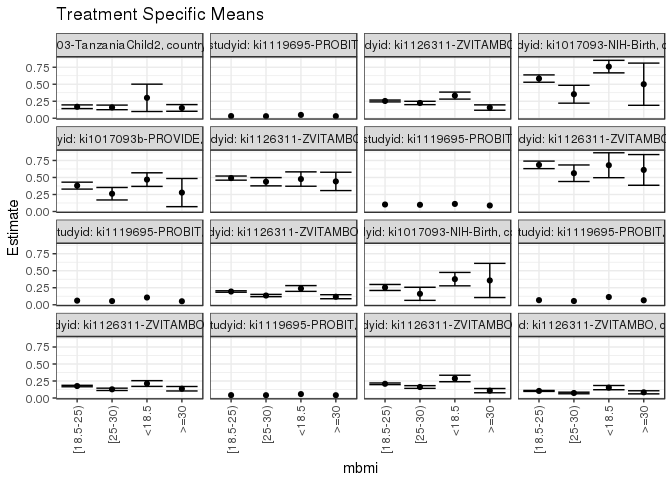

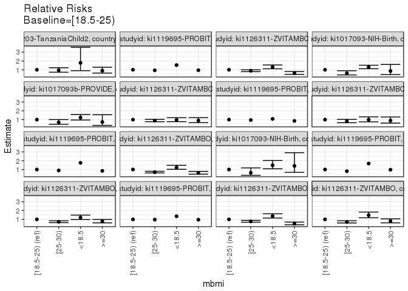

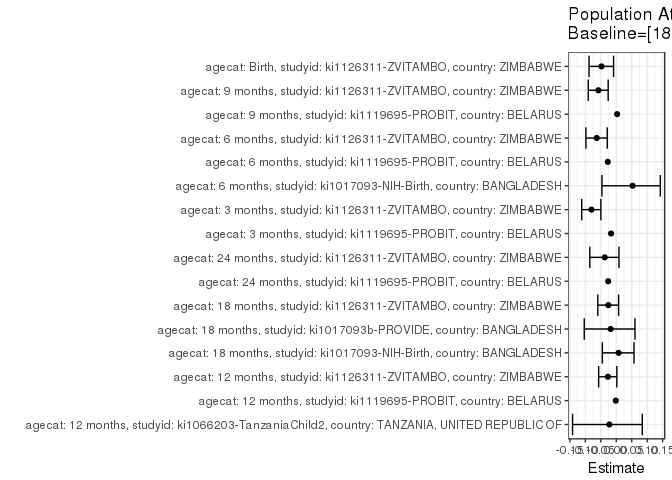

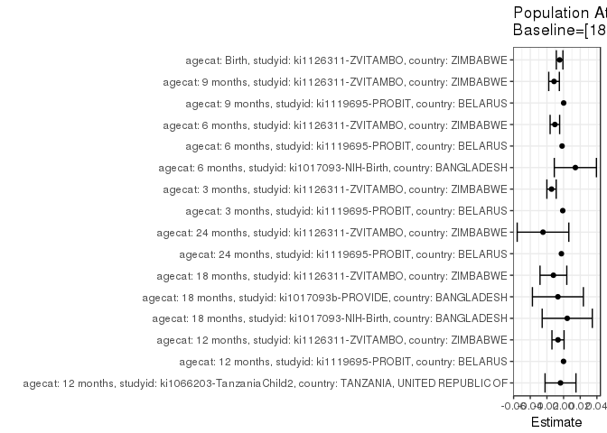

## Results Table

### Parameter: TSM

| agecat | studyid | country | intervention_level | baseline_level | estimate | ci_lower | ci_upper |
| --- | --- | --- | --- | --- | --- | --- | --- |
| Birth | ki1126311-ZVITAMBO | ZIMBABWE | [18.5-25) | NA | 0.1039709 | 0.0966058 | 0.1113360 |
| Birth | ki1126311-ZVITAMBO | ZIMBABWE | <18.5 | NA | 0.1529412 | 0.1217016 | 0.1841807 |
| Birth | ki1126311-ZVITAMBO | ZIMBABWE | [25-30) | NA | 0.0737705 | 0.0621739 | 0.0853671 |
| Birth | ki1126311-ZVITAMBO | ZIMBABWE | >=30 | NA | 0.0836237 | 0.0609764 | 0.1062710 |
| 3 months | ki1119695-PROBIT | BELARUS | [18.5-25) | NA | 0.0604521 | NA | NA |
| 3 months | ki1119695-PROBIT | BELARUS | <18.5 | NA | 0.1062992 | NA | NA |
| 3 months | ki1119695-PROBIT | BELARUS | [25-30) | NA | 0.0539610 | NA | NA |
| 3 months | ki1119695-PROBIT | BELARUS | >=30 | NA | 0.0510067 | NA | NA |
| 3 months | ki1126311-ZVITAMBO | ZIMBABWE | [18.5-25) | NA | 0.1943030 | 0.1836512 | 0.2049548 |
| 3 months | ki1126311-ZVITAMBO | ZIMBABWE | <18.5 | NA | 0.2390746 | 0.1966869 | 0.2814622 |
| 3 months | ki1126311-ZVITAMBO | ZIMBABWE | [25-30) | NA | 0.1353712 | 0.1186222 | 0.1521201 |
| 3 months | ki1126311-ZVITAMBO | ZIMBABWE | >=30 | NA | 0.1179039 | 0.0883670 | 0.1474409 |
| 6 months | ki1017093-NIH-Birth | BANGLADESH | [18.5-25) | NA | 0.2540107 | 0.2098527 | 0.2981687 |
| 6 months | ki1017093-NIH-Birth | BANGLADESH | <18.5 | NA | 0.3763441 | 0.2777896 | 0.4748986 |
| 6 months | ki1017093-NIH-Birth | BANGLADESH | [25-30) | NA | 0.1607143 | 0.0644332 | 0.2569954 |
| 6 months | ki1017093-NIH-Birth | BANGLADESH | >=30 | NA | 0.3571429 | 0.1059154 | 0.6083703 |
| 6 months | ki1119695-PROBIT | BELARUS | [18.5-25) | NA | 0.0675818 | NA | NA |
| 6 months | ki1119695-PROBIT | BELARUS | <18.5 | NA | 0.1133603 | NA | NA |
| 6 months | ki1119695-PROBIT | BELARUS | [25-30) | NA | 0.0546968 | NA | NA |
| 6 months | ki1119695-PROBIT | BELARUS | >=30 | NA | 0.0658263 | NA | NA |
| 6 months | ki1126311-ZVITAMBO | ZIMBABWE | [18.5-25) | NA | 0.1758763 | 0.1651609 | 0.1865917 |
| 6 months | ki1126311-ZVITAMBO | ZIMBABWE | <18.5 | NA | 0.2127072 | 0.1705488 | 0.2548655 |
| 6 months | ki1126311-ZVITAMBO | ZIMBABWE | [25-30) | NA | 0.1277174 | 0.1106653 | 0.1447695 |
| 6 months | ki1126311-ZVITAMBO | ZIMBABWE | >=30 | NA | 0.1364706 | 0.1038312 | 0.1691100 |
| 9 months | ki1119695-PROBIT | BELARUS | [18.5-25) | NA | 0.0423139 | NA | NA |
| 9 months | ki1119695-PROBIT | BELARUS | <18.5 | NA | 0.0573770 | NA | NA |
| 9 months | ki1119695-PROBIT | BELARUS | [25-30) | NA | 0.0411373 | NA | NA |
| 9 months | ki1119695-PROBIT | BELARUS | >=30 | NA | 0.0409027 | NA | NA |
| 9 months | ki1126311-ZVITAMBO | ZIMBABWE | [18.5-25) | NA | 0.2089087 | 0.1970168 | 0.2208005 |
| 9 months | ki1126311-ZVITAMBO | ZIMBABWE | <18.5 | NA | 0.2869565 | 0.2392214 | 0.3346916 |
| 9 months | ki1126311-ZVITAMBO | ZIMBABWE | [25-30) | NA | 0.1616541 | 0.1418680 | 0.1814402 |
| 9 months | ki1126311-ZVITAMBO | ZIMBABWE | >=30 | NA | 0.1082474 | 0.0773305 | 0.1391644 |
| 12 months | ki1066203-TanzaniaChild2 | TANZANIA, UNITED REPUBLIC OF | [18.5-25) | NA | 0.1684783 | 0.1414280 | 0.1955285 |
| 12 months | ki1066203-TanzaniaChild2 | TANZANIA, UNITED REPUBLIC OF | <18.5 | NA | 0.3000000 | 0.0990924 | 0.5009076 |
| 12 months | ki1066203-TanzaniaChild2 | TANZANIA, UNITED REPUBLIC OF | [25-30) | NA | 0.1589404 | 0.1252595 | 0.1926213 |
| 12 months | ki1066203-TanzaniaChild2 | TANZANIA, UNITED REPUBLIC OF | >=30 | NA | 0.1512195 | 0.1021596 | 0.2002794 |
| 12 months | ki1119695-PROBIT | BELARUS | [18.5-25) | NA | 0.0317626 | NA | NA |
| 12 months | ki1119695-PROBIT | BELARUS | <18.5 | NA | 0.0485830 | NA | NA |
| 12 months | ki1119695-PROBIT | BELARUS | [25-30) | NA | 0.0298071 | NA | NA |
| 12 months | ki1119695-PROBIT | BELARUS | >=30 | NA | 0.0301783 | NA | NA |
| 12 months | ki1126311-ZVITAMBO | ZIMBABWE | [18.5-25) | NA | 0.2535457 | 0.2400946 | 0.2669967 |
| 12 months | ki1126311-ZVITAMBO | ZIMBABWE | <18.5 | NA | 0.3322981 | 0.2808449 | 0.3837514 |
| 12 months | ki1126311-ZVITAMBO | ZIMBABWE | [25-30) | NA | 0.2242152 | 0.1997330 | 0.2486975 |
| 12 months | ki1126311-ZVITAMBO | ZIMBABWE | >=30 | NA | 0.1569231 | 0.1173754 | 0.1964708 |
| 18 months | ki1017093-NIH-Birth | BANGLADESH | [18.5-25) | NA | 0.5830721 | 0.5289077 | 0.6372365 |
| 18 months | ki1017093-NIH-Birth | BANGLADESH | <18.5 | NA | 0.7590361 | 0.6669306 | 0.8511417 |
| 18 months | ki1017093-NIH-Birth | BANGLADESH | [25-30) | NA | 0.3529412 | 0.2216439 | 0.4842384 |
| 18 months | ki1017093-NIH-Birth | BANGLADESH | >=30 | NA | 0.5000000 | 0.1897673 | 0.8102327 |
| 18 months | ki1017093b-PROVIDE | BANGLADESH | [18.5-25) | NA | 0.3800000 | 0.3291026 | 0.4308974 |
| 18 months | ki1017093b-PROVIDE | BANGLADESH | <18.5 | NA | 0.4687500 | 0.3688360 | 0.5686640 |
| 18 months | ki1017093b-PROVIDE | BANGLADESH | [25-30) | NA | 0.2613636 | 0.1694799 | 0.3532473 |
| 18 months | ki1017093b-PROVIDE | BANGLADESH | >=30 | NA | 0.2777778 | 0.0706732 | 0.4848824 |
| 18 months | ki1126311-ZVITAMBO | ZIMBABWE | [18.5-25) | NA | 0.4907498 | 0.4601646 | 0.5213350 |
| 18 months | ki1126311-ZVITAMBO | ZIMBABWE | <18.5 | NA | 0.4767442 | 0.3711472 | 0.5823412 |
| 18 months | ki1126311-ZVITAMBO | ZIMBABWE | [25-30) | NA | 0.4375000 | 0.3767101 | 0.4982899 |
| 18 months | ki1126311-ZVITAMBO | ZIMBABWE | >=30 | NA | 0.4423077 | 0.3072688 | 0.5773466 |
| 24 months | ki1119695-PROBIT | BELARUS | [18.5-25) | NA | 0.1026178 | NA | NA |
| 24 months | ki1119695-PROBIT | BELARUS | <18.5 | NA | 0.1111111 | NA | NA |
| 24 months | ki1119695-PROBIT | BELARUS | [25-30) | NA | 0.0981308 | NA | NA |
| 24 months | ki1119695-PROBIT | BELARUS | >=30 | NA | 0.0879121 | NA | NA |
| 24 months | ki1126311-ZVITAMBO | ZIMBABWE | [18.5-25) | NA | 0.6851852 | 0.6297131 | 0.7406573 |
| 24 months | ki1126311-ZVITAMBO | ZIMBABWE | <18.5 | NA | 0.6800000 | 0.4969017 | 0.8630983 |
| 24 months | ki1126311-ZVITAMBO | ZIMBABWE | [25-30) | NA | 0.5625000 | 0.4408015 | 0.6841985 |
| 24 months | ki1126311-ZVITAMBO | ZIMBABWE | >=30 | NA | 0.6111111 | 0.3856034 | 0.8366188 |

### Parameter: E(Y)

| agecat | studyid | country | intervention_level | baseline_level | estimate | ci_lower | ci_upper |
| --- | --- | --- | --- | --- | --- | --- | --- |
| Birth | ki1126311-ZVITAMBO | ZIMBABWE | NA | NA | 0.0992319 | 0.0932615 | 0.1052022 |
| 3 months | ki1119695-PROBIT | BELARUS | NA | NA | 0.0594489 | NA | NA |
| 3 months | ki1126311-ZVITAMBO | ZIMBABWE | NA | NA | 0.1798478 | 0.1712972 | 0.1883984 |
| 6 months | ki1017093-NIH-Birth | BANGLADESH | NA | NA | 0.2681564 | 0.2306532 | 0.3056597 |
| 6 months | ki1119695-PROBIT | BELARUS | NA | NA | 0.0657752 | NA | NA |
| 6 months | ki1126311-ZVITAMBO | ZIMBABWE | NA | NA | 0.1654241 | 0.1567862 | 0.1740620 |
| 9 months | ki1119695-PROBIT | BELARUS | NA | NA | 0.0424290 | NA | NA |
| 9 months | ki1126311-ZVITAMBO | ZIMBABWE | NA | NA | 0.1974668 | 0.1878276 | 0.2071060 |
| 12 months | ki1066203-TanzaniaChild2 | TANZANIA, UNITED REPUBLIC OF | NA | NA | 0.1647808 | 0.1454375 | 0.1841241 |
| 12 months | ki1119695-PROBIT | BELARUS | NA | NA | 0.0317096 | NA | NA |
| 12 months | ki1126311-ZVITAMBO | ZIMBABWE | NA | NA | 0.2468431 | 0.2357274 | 0.2579588 |
| 18 months | ki1017093-NIH-Birth | BANGLADESH | NA | NA | 0.5874730 | 0.5425832 | 0.6323628 |
| 18 months | ki1017093b-PROVIDE | BANGLADESH | NA | NA | 0.3731884 | 0.3328048 | 0.4135720 |
| 18 months | ki1126311-ZVITAMBO | ZIMBABWE | NA | NA | 0.4785362 | 0.4525542 | 0.5045183 |
| 24 months | ki1119695-PROBIT | BELARUS | NA | NA | 0.1000000 | NA | NA |
| 24 months | ki1126311-ZVITAMBO | ZIMBABWE | NA | NA | 0.6604775 | 0.6126125 | 0.7083424 |

### Parameter: RR

| agecat | studyid | country | intervention_level | baseline_level | estimate | ci_lower | ci_upper |
| --- | --- | --- | --- | --- | --- | --- | --- |
| Birth | ki1126311-ZVITAMBO | ZIMBABWE | [18.5-25) | [18.5-25) | 1.0000000 | 1.0000000 | 1.0000000 |
| Birth | ki1126311-ZVITAMBO | ZIMBABWE | <18.5 | [18.5-25) | 1.4709998 | 1.1850072 | 1.8260147 |
| Birth | ki1126311-ZVITAMBO | ZIMBABWE | [25-30) | [18.5-25) | 0.7095302 | 0.5971573 | 0.8430493 |
| Birth | ki1126311-ZVITAMBO | ZIMBABWE | >=30 | [18.5-25) | 0.8042990 | 0.6079156 | 1.0641230 |
| 3 months | ki1119695-PROBIT | BELARUS | [18.5-25) | [18.5-25) | 1.0000000 | NA | NA |
| 3 months | ki1119695-PROBIT | BELARUS | <18.5 | [18.5-25) | 1.7584034 | NA | NA |
| 3 months | ki1119695-PROBIT | BELARUS | [25-30) | [18.5-25) | 0.8926232 | NA | NA |
| 3 months | ki1119695-PROBIT | BELARUS | >=30 | [18.5-25) | 0.8437539 | NA | NA |
| 3 months | ki1126311-ZVITAMBO | ZIMBABWE | [18.5-25) | [18.5-25) | 1.0000000 | 1.0000000 | 1.0000000 |
| 3 months | ki1126311-ZVITAMBO | ZIMBABWE | <18.5 | [18.5-25) | 1.2304215 | 1.0220151 | 1.4813256 |
| 3 months | ki1126311-ZVITAMBO | ZIMBABWE | [25-30) | [18.5-25) | 0.6967016 | 0.6085202 | 0.7976615 |
| 3 months | ki1126311-ZVITAMBO | ZIMBABWE | >=30 | [18.5-25) | 0.6068046 | 0.4695439 | 0.7841904 |
| 6 months | ki1017093-NIH-Birth | BANGLADESH | [18.5-25) | [18.5-25) | 1.0000000 | 1.0000000 | 1.0000000 |
| 6 months | ki1017093-NIH-Birth | BANGLADESH | <18.5 | [18.5-25) | 1.4816072 | 1.0819925 | 2.0288125 |
| 6 months | ki1017093-NIH-Birth | BANGLADESH | [25-30) | [18.5-25) | 0.6327068 | 0.3390716 | 1.1806291 |
| 6 months | ki1017093-NIH-Birth | BANGLADESH | >=30 | [18.5-25) | 1.4060150 | 0.6812403 | 2.9018811 |
| 6 months | ki1119695-PROBIT | BELARUS | [18.5-25) | [18.5-25) | 1.0000000 | NA | NA |
| 6 months | ki1119695-PROBIT | BELARUS | <18.5 | [18.5-25) | 1.6773785 | NA | NA |
| 6 months | ki1119695-PROBIT | BELARUS | [25-30) | [18.5-25) | 0.8093416 | NA | NA |
| 6 months | ki1119695-PROBIT | BELARUS | >=30 | [18.5-25) | 0.9740240 | NA | NA |
| 6 months | ki1126311-ZVITAMBO | ZIMBABWE | [18.5-25) | [18.5-25) | 1.0000000 | 1.0000000 | 1.0000000 |
| 6 months | ki1126311-ZVITAMBO | ZIMBABWE | <18.5 | [18.5-25) | 1.2094136 | 0.9829312 | 1.4880811 |
| 6 months | ki1126311-ZVITAMBO | ZIMBABWE | [25-30) | [18.5-25) | 0.7261774 | 0.6270560 | 0.8409674 |
| 6 months | ki1126311-ZVITAMBO | ZIMBABWE | >=30 | [18.5-25) | 0.7759465 | 0.6062408 | 0.9931580 |
| 9 months | ki1119695-PROBIT | BELARUS | [18.5-25) | [18.5-25) | 1.0000000 | NA | NA |
| 9 months | ki1119695-PROBIT | BELARUS | <18.5 | [18.5-25) | 1.3559867 | NA | NA |
| 9 months | ki1119695-PROBIT | BELARUS | [25-30) | [18.5-25) | 0.9721948 | NA | NA |
| 9 months | ki1119695-PROBIT | BELARUS | >=30 | [18.5-25) | 0.9666494 | NA | NA |
| 9 months | ki1126311-ZVITAMBO | ZIMBABWE | [18.5-25) | [18.5-25) | 1.0000000 | 1.0000000 | 1.0000000 |
| 9 months | ki1126311-ZVITAMBO | ZIMBABWE | <18.5 | [18.5-25) | 1.3735978 | 1.1521318 | 1.6376347 |
| 9 months | ki1126311-ZVITAMBO | ZIMBABWE | [25-30) | [18.5-25) | 0.7738028 | 0.6760925 | 0.8856344 |
| 9 months | ki1126311-ZVITAMBO | ZIMBABWE | >=30 | [18.5-25) | 0.5181566 | 0.3872408 | 0.6933316 |
| 12 months | ki1066203-TanzaniaChild2 | TANZANIA, UNITED REPUBLIC OF | [18.5-25) | [18.5-25) | 1.0000000 | 1.0000000 | 1.0000000 |
| 12 months | ki1066203-TanzaniaChild2 | TANZANIA, UNITED REPUBLIC OF | <18.5 | [18.5-25) | 1.7806452 | 0.8943181 | 3.5453798 |
| 12 months | ki1066203-TanzaniaChild2 | TANZANIA, UNITED REPUBLIC OF | [25-30) | [18.5-25) | 0.9433882 | 0.7231479 | 1.2307042 |
| 12 months | ki1066203-TanzaniaChild2 | TANZANIA, UNITED REPUBLIC OF | >=30 | [18.5-25) | 0.8975610 | 0.6249662 | 1.2890548 |
| 12 months | ki1119695-PROBIT | BELARUS | [18.5-25) | [18.5-25) | 1.0000000 | NA | NA |
| 12 months | ki1119695-PROBIT | BELARUS | <18.5 | [18.5-25) | 1.5295679 | NA | NA |
| 12 months | ki1119695-PROBIT | BELARUS | [25-30) | [18.5-25) | 0.9384360 | NA | NA |
| 12 months | ki1119695-PROBIT | BELARUS | >=30 | [18.5-25) | 0.9501226 | NA | NA |
| 12 months | ki1126311-ZVITAMBO | ZIMBABWE | [18.5-25) | [18.5-25) | 1.0000000 | 1.0000000 | 1.0000000 |
| 12 months | ki1126311-ZVITAMBO | ZIMBABWE | <18.5 | [18.5-25) | 1.3106047 | 1.1127248 | 1.5436744 |
| 12 months | ki1126311-ZVITAMBO | ZIMBABWE | [25-30) | [18.5-25) | 0.8843190 | 0.7832260 | 0.9984604 |
| 12 months | ki1126311-ZVITAMBO | ZIMBABWE | >=30 | [18.5-25) | 0.6189145 | 0.4783890 | 0.8007189 |
| 18 months | ki1017093-NIH-Birth | BANGLADESH | [18.5-25) | [18.5-25) | 1.0000000 | 1.0000000 | 1.0000000 |
| 18 months | ki1017093-NIH-Birth | BANGLADESH | <18.5 | [18.5-25) | 1.3017878 | 1.1173032 | 1.5167338 |
| 18 months | ki1017093-NIH-Birth | BANGLADESH | [25-30) | [18.5-25) | 0.6053131 | 0.4125321 | 0.8881829 |
| 18 months | ki1017093-NIH-Birth | BANGLADESH | >=30 | [18.5-25) | 0.8575269 | 0.4579095 | 1.6058901 |
| 18 months | ki1017093b-PROVIDE | BANGLADESH | [18.5-25) | [18.5-25) | 1.0000000 | 1.0000000 | 1.0000000 |
| 18 months | ki1017093b-PROVIDE | BANGLADESH | <18.5 | [18.5-25) | 1.2335526 | 0.9590218 | 1.5866710 |
| 18 months | ki1017093b-PROVIDE | BANGLADESH | [25-30) | [18.5-25) | 0.6877990 | 0.4721472 | 1.0019493 |
| 18 months | ki1017093b-PROVIDE | BANGLADESH | >=30 | [18.5-25) | 0.7309942 | 0.3427130 | 1.5591834 |
| 18 months | ki1126311-ZVITAMBO | ZIMBABWE | [18.5-25) | [18.5-25) | 1.0000000 | 1.0000000 | 1.0000000 |
| 18 months | ki1126311-ZVITAMBO | ZIMBABWE | <18.5 | [18.5-25) | 0.9714609 | 0.7717833 | 1.2227995 |
| 18 months | ki1126311-ZVITAMBO | ZIMBABWE | [25-30) | [18.5-25) | 0.8914931 | 0.7655636 | 1.0381370 |
| 18 months | ki1126311-ZVITAMBO | ZIMBABWE | >=30 | [18.5-25) | 0.9012897 | 0.6599903 | 1.2308107 |
| 24 months | ki1119695-PROBIT | BELARUS | [18.5-25) | [18.5-25) | 1.0000000 | NA | NA |
| 24 months | ki1119695-PROBIT | BELARUS | <18.5 | [18.5-25) | 1.0827664 | NA | NA |
| 24 months | ki1119695-PROBIT | BELARUS | [25-30) | [18.5-25) | 0.9562750 | NA | NA |
| 24 months | ki1119695-PROBIT | BELARUS | >=30 | [18.5-25) | 0.8566943 | NA | NA |
| 24 months | ki1126311-ZVITAMBO | ZIMBABWE | [18.5-25) | [18.5-25) | 1.0000000 | 1.0000000 | 1.0000000 |
| 24 months | ki1126311-ZVITAMBO | ZIMBABWE | <18.5 | [18.5-25) | 0.9924324 | 0.7491873 | 1.3146541 |
| 24 months | ki1126311-ZVITAMBO | ZIMBABWE | [25-30) | [18.5-25) | 0.8209459 | 0.6516144 | 1.0342807 |
| 24 months | ki1126311-ZVITAMBO | ZIMBABWE | >=30 | [18.5-25) | 0.8918919 | 0.6112803 | 1.3013197 |

### Parameter: PAR

| agecat | studyid | country | intervention_level | baseline_level | estimate | ci_lower | ci_upper |
| --- | --- | --- | --- | --- | --- | --- | --- |
| Birth | ki1126311-ZVITAMBO | ZIMBABWE | [18.5-25) | NA | -0.0047390 | -0.0086873 | -0.0007908 |
| 3 months | ki1119695-PROBIT | BELARUS | [18.5-25) | NA | -0.0010032 | NA | NA |
| 3 months | ki1126311-ZVITAMBO | ZIMBABWE | [18.5-25) | NA | -0.0144552 | -0.0200569 | -0.0088535 |
| 6 months | ki1017093-NIH-Birth | BANGLADESH | [18.5-25) | NA | 0.0141457 | -0.0111588 | 0.0394503 |
| 6 months | ki1119695-PROBIT | BELARUS | [18.5-25) | NA | -0.0018067 | NA | NA |
| 6 months | ki1126311-ZVITAMBO | ZIMBABWE | [18.5-25) | NA | -0.0104522 | -0.0161762 | -0.0047281 |
| 9 months | ki1119695-PROBIT | BELARUS | [18.5-25) | NA | 0.0001151 | NA | NA |
| 9 months | ki1126311-ZVITAMBO | ZIMBABWE | [18.5-25) | NA | -0.0114419 | -0.0178088 | -0.0050749 |
| 12 months | ki1066203-TanzaniaChild2 | TANZANIA, UNITED REPUBLIC OF | [18.5-25) | NA | -0.0036975 | -0.0222488 | 0.0148538 |
| 12 months | ki1119695-PROBIT | BELARUS | [18.5-25) | NA | -0.0000530 | NA | NA |
| 12 months | ki1126311-ZVITAMBO | ZIMBABWE | [18.5-25) | NA | -0.0067026 | -0.0139772 | 0.0005721 |
| 18 months | ki1017093-NIH-Birth | BANGLADESH | [18.5-25) | NA | 0.0044009 | -0.0257024 | 0.0345042 |
| 18 months | ki1017093b-PROVIDE | BANGLADESH | [18.5-25) | NA | -0.0068116 | -0.0374101 | 0.0237869 |
| 18 months | ki1126311-ZVITAMBO | ZIMBABWE | [18.5-25) | NA | -0.0122135 | -0.0282870 | 0.0038600 |
| 24 months | ki1119695-PROBIT | BELARUS | [18.5-25) | NA | -0.0026178 | NA | NA |
| 24 months | ki1126311-ZVITAMBO | ZIMBABWE | [18.5-25) | NA | -0.0247077 | -0.0557015 | 0.0062860 |

### Parameter: PAF

| agecat | studyid | country | intervention_level | baseline_level | estimate | ci_lower | ci_upper |
| --- | --- | --- | --- | --- | --- | --- | --- |
| Birth | ki1126311-ZVITAMBO | ZIMBABWE | [18.5-25) | NA | -0.0477570 | -0.0882273 | -0.0087917 |
| 3 months | ki1119695-PROBIT | BELARUS | [18.5-25) | NA | -0.0168747 | NA | NA |
| 3 months | ki1126311-ZVITAMBO | ZIMBABWE | [18.5-25) | NA | -0.0803746 | -0.1118478 | -0.0497924 |
| 6 months | ki1017093-NIH-Birth | BANGLADESH | [18.5-25) | NA | 0.0527518 | -0.0463760 | 0.1424888 |
| 6 months | ki1119695-PROBIT | BELARUS | [18.5-25) | NA | -0.0274676 | NA | NA |
| 6 months | ki1126311-ZVITAMBO | ZIMBABWE | [18.5-25) | NA | -0.0631841 | -0.0982616 | -0.0292270 |
| 9 months | ki1119695-PROBIT | BELARUS | [18.5-25) | NA | 0.0027139 | NA | NA |
| 9 months | ki1126311-ZVITAMBO | ZIMBABWE | [18.5-25) | NA | -0.0579433 | -0.0906214 | -0.0262443 |
| 12 months | ki1066203-TanzaniaChild2 | TANZANIA, UNITED REPUBLIC OF | [18.5-25) | NA | -0.0224389 | -0.1414320 | 0.0841493 |
| 12 months | ki1119695-PROBIT | BELARUS | [18.5-25) | NA | -0.0016715 | NA | NA |
| 12 months | ki1126311-ZVITAMBO | ZIMBABWE | [18.5-25) | NA | -0.0271531 | -0.0570422 | 0.0018909 |
| 18 months | ki1017093-NIH-Birth | BANGLADESH | [18.5-25) | NA | 0.0074912 | -0.0451028 | 0.0574385 |
| 18 months | ki1017093b-PROVIDE | BANGLADESH | [18.5-25) | NA | -0.0182524 | -0.1036415 | 0.0605301 |
| 18 months | ki1126311-ZVITAMBO | ZIMBABWE | [18.5-25) | NA | -0.0255227 | -0.0596938 | 0.0075466 |
| 24 months | ki1119695-PROBIT | BELARUS | [18.5-25) | NA | -0.0261780 | NA | NA |
| 24 months | ki1126311-ZVITAMBO | ZIMBABWE | [18.5-25) | NA | -0.0374089 | -0.0856609 | 0.0086985 |